# Using the data collected from existing customers, build a model that will help the marketing team identify potential customers who are relatively more likely to subscribe term deposit and thus increas

###### CatBoost Model Results - matrix X2

```python
TP = 747
FP = 449
FN = 848
TN = 11520
Recall = TP/(TP+FN)
Precision = TP/(TP+FP)
print('Recall [TP/(TP+FN)] for CatBoost_Ensemble = {0:.2f}'.format(Recall))
print('Precision [TP/(TP+FP)] for CatBoost_Ensemble = {0:.2f}'.format(Precision))
print('F1 Score [2.Precision.Recall / (Precision + Recall)] for CatBoost_Ensemble = {0:.2f}'.format((2*Recall*Precision)/(Recall+Precision)))
print('Accuracy [(TP+TN)/(TP+TN+FP+FN)] for CatBoost_Ensemble = {0:.2f}'.format((TP+TN)/(TP+TN+FP+FN)))
```

```
Recall [TP/(TP+FN)] for CatBoost_Ensemble = 0.47
Precision [TP/(TP+FP)] for CatBoost_Ensemble = 0.62
F1 Score [2.Precision.Recall / (Precision + Recall)] for CatBoost_Ensemble = 0.54
Accuracy [(TP+TN)/(TP+TN+FP+FN)] for CatBoost_Ensemble = 0.90
```

###### CatBoost Ensemble - matrix X3

```python
cbcl.fit(X3_train, y_train)
```

```
<catboost.core.CatBoostClassifier at 0x2f4b7c65b50>
```

```
0.9070333235033913
```

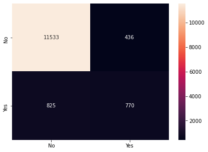

```python
# Get predicted classes
y_predict8 = cbcl.predict(X3_test)

print(cbcl.score(X3_test, y_test))

cm8=metrics.confusion_matrix(y_test, y_predict8, labels=[0, 1])

df_cm8 = pd.DataFrame(cm8, index = [i for i in ["No","Yes"]],
                  columns = [i for i in ["No","Yes"]])
plt.figure(figsize = (7,5))
sns.heatmap(df_cm8, annot=True ,fmt='g')
```

###### CatBoost Model Results - matrix X3

```python
TP = 770
FP = 436
FN = 825
TN = 11533
Recall = TP/(TP+FN)
Precision = TP/(TP+FP)
print('Recall [TP/(TP+FN)] for CatBoost_Ensemble = {0:.2f}'.format(Recall))
print('Precision [TP/(TP+FP)] for CatBoost_Ensemble = {0:.2f}'.format(Precision))
print('F1 Score [2.Precision.Recall / (Precision + Recall)] for CatBoost_Ensemble = {0:.2f}'.format((2*Recall*Precision)/(Recall+Precision)))
print('Accuracy [(TP+TN)/(TP+TN+FP+FN)] for CatBoost_Ensemble = {0:.2f}'.format((TP+TN)/(TP+TN+FP+FN)))
```

```
Recall [TP/(TP+FN)] for CatBoost_Ensemble = 0.48
Precision [TP/(TP+FP)] for CatBoost_Ensemble = 0.64
F1 Score [2.Precision.Recall / (Precision + Recall)] for CatBoost_Ensemble = 0.55
Accuracy [(TP+TN)/(TP+TN+FP+FN)] for CatBoost_Ensemble = 0.91
```

###### CatBoost performance using different matrices

- Recall, Precision, Accuracy & F1-Score increase from matrix X2 to X3, where we drop age, as its pairplot with other variable with a hue=Target shows no obvious relationship, also drop previous because its IQR is 0
- I therefore create another matrix X4 to refine CatBoost to with its best matrix

```python
X4 = X1.copy()
X4 = X4.drop(['age', 'previous'], axis=1, inplace=False)
X4.info()
```

```
<class 'pandas.core.frame.DataFrame'>
RangeIndex: 45211 entries, 0 to 45210
Data columns (total 40 columns):
 #   Column               Non-Null Count  Dtype
---  ------               --------------  -----
 0   default              45211 non-null  int64
 1   balance              45211 non-null  int64
 2   housing              45211 non-null  int64
 3   loan                 45211 non-null  int64
 4   day                  45211 non-null  int64
 5   duration             45211 non-null  int64
 6   campaign             45211 non-null  int64
 7   pdays                45211 non-null  int64
 8   job_blue-collar      45211 non-null  uint8
 9   job_entrepreneur     45211 non-null  uint8
```

[output cut: 32 more lines]

```python
X4_train, X4_test, y_train, y_test = train_test_split(X4, y, test_size=0.3, random_state=3)
X4_train.head()
```

|  | default | balance | housing | loan | day | duration | campaign | pdays | job_blue-collar | job_entrepreneur | ... | month_jul | month_jun | month_mar | month_may | month_nov | month_oct | month_sep | poutcome_other | poutcome_success | poutcome_unknown |
| --- | --- | --- | --- | --- | --- | --- | --- | --- | --- | --- | --- | --- | --- | --- | --- | --- | --- | --- | --- | --- | --- |
| 24103 | 0 | 372 | 0 | 1 | 29 | 11 | 1 | -1 | 0 | 0 | ... | 0 | 0 | 0 | 0 | 0 | 1 | 0 | 0 | 0 | 1 |
| 34104 | 0 | 2503 | 0 | 0 | 30 | 121 | 1 | 63 | 0 | 0 | ... | 0 | 0 | 0 | 0 | 0 | 0 | 0 | 0 | 0 | 0 |
| 14387 | 0 | 808 | 0 | 0 | 14 | 417 | 3 | -1 | 0 | 0 | ... | 1 | 0 | 0 | 0 | 0 | 0 | 0 | 0 | 0 | 1 |
| 13641 | 0 | -139 | 0 | 0 | 9 | 328 | 3 | -1 | 0 | 0 | ... | 1 | 0 | 0 | 0 | 0 | 0 | 0 | 0 | 0 | 1 |
| 37104 | 0 | 2171 | 1 | 1 | 13 | 318 | 5 | 176 | 0 | 0 | ... | 0 | 0 | 0 | 1 | 0 | 0 | 0 | 0 | 1 | 0 |

5 rows × 40 columns

###### CatBoost Ensemble - matrix X4

```python
cbcl.fit(X4_train, y_train)
```

```
<catboost.core.CatBoostClassifier at 0x2f4b7c65b50>
```

```
0.9093187850191684
```

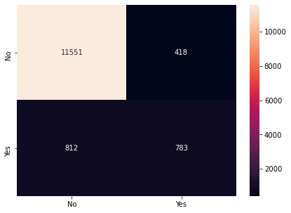

```python
# Get predicted classes
y_predict8 = cbcl.predict(X4_test)

print(cbcl.score(X4_test, y_test))

cm8=metrics.confusion_matrix(y_test, y_predict8, labels=[0, 1])

df_cm8 = pd.DataFrame(cm8, index = [i for i in ["No","Yes"]],
                  columns = [i for i in ["No","Yes"]])
plt.figure(figsize = (7,5))
sns.heatmap(df_cm8, annot=True ,fmt='g')
```

```python
# Create report for final evaluation of models at the end
report8 = classification_report(y_test, y_predict8, output_dict=True)
```

###### CatBoost Model Results - matrix X4

```python
TP = 783
FP = 418
FN = 812
TN = 11551
Recall = TP/(TP+FN)
Precision = TP/(TP+FP)
print('Recall [TP/(TP+FN)] for CatBoost_Ensemble = {0:.2f}'.format(Recall))
print('Precision [TP/(TP+FP)] for CatBoost_Ensemble = {0:.2f}'.format(Precision))
print('F1 Score [2.Precision.Recall / (Precision + Recall)] for CatBoost_Ensemble = {0:.2f}'.format((2*Recall*Precision)/(Recall+Precision)))
print('Accuracy [(TP+TN)/(TP+TN+FP+FN)] for CatBoost_Ensemble = {0:.2f}'.format((TP+TN)/(TP+TN+FP+FN)))
```

```
Recall [TP/(TP+FN)] for CatBoost_Ensemble = 0.49
Precision [TP/(TP+FP)] for CatBoost_Ensemble = 0.65
F1 Score [2.Precision.Recall / (Precision + Recall)] for CatBoost_Ensemble = 0.56
Accuracy [(TP+TN)/(TP+TN+FP+FN)] for CatBoost_Ensemble = 0.91
```

###### XGBoost Ensemble - matrix X1

```python
from xgboost import XGBClassifier

xgbcl = XGBClassifier(n_estimators=100,max_depth=6,random_state=3,base_score=0.20)
xgbcl.fit(X1_train, y_train)
```

```
XGBClassifier(base_score=0.2, booster='gbtree', colsample_bylevel=1,
              colsample_bynode=1, colsample_bytree=1, gamma=0, gpu_id=-1,
              importance_type='gain', interaction_constraints='',
              learning_rate=0.300000012, max_delta_step=0, max_depth=6,
              min_child_weight=1, missing=nan, monotone_constraints='()',
              n_estimators=100, n_jobs=0, num_parallel_tree=1, random_state=3,
              reg_alpha=0, reg_lambda=1, scale_pos_weight=1, subsample=1,
              tree_method='exact', validate_parameters=1, verbosity=None)
```

```
0.9085815393689177
```

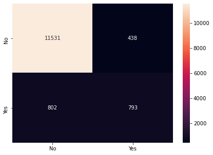

```python
# Get predicted classes
y_predict9 = xgbcl.predict(X1_test)

print(xgbcl.score(X1_test, y_test))

cm9=metrics.confusion_matrix(y_test, y_predict9, labels=[0, 1])

df_cm9 = pd.DataFrame(cm9, index = [i for i in ["No","Yes"]],
                  columns = [i for i in ["No","Yes"]])
plt.figure(figsize = (7,5))
sns.heatmap(df_cm9, annot=True ,fmt='g')
```

###### XGBoost Model Results - matrix X1

```python
TP = 793
FP = 438
FN = 802
TN = 11531
Recall = TP/(TP+FN)
Precision = TP/(TP+FP)
print('Recall [TP/(TP+FN)] for XGBoost_Ensemble = {0:.2f}'.format(Recall))
print('Precision [TP/(TP+FP)] for XGBoost_Ensemble = {0:.2f}'.format(Precision))
print('F1 Score [2.Precision.Recall / (Precision + Recall)] for XGBoost_Ensemble = {0:.2f}'.format((2*Recall*Precision)/(Recall+Precision)))
print('Accuracy [(TP+TN)/(TP+TN+FP+FN)] for XGBoost_Ensemble = {0:.2f}'.format((TP+TN)/(TP+TN+FP+FN)))
```

```
Recall [TP/(TP+FN)] for XGBoost_Ensemble = 0.50
Precision [TP/(TP+FP)] for XGBoost_Ensemble = 0.64
F1 Score [2.Precision.Recall / (Precision + Recall)] for XGBoost_Ensemble = 0.56
Accuracy [(TP+TN)/(TP+TN+FP+FN)] for XGBoost_Ensemble = 0.91
```

###### XGBoost Ensemble - matrix X2

```python
xgbcl.fit(X2_train, y_train)
```

```
XGBClassifier(base_score=0.2, booster='gbtree', colsample_bylevel=1,
              colsample_bynode=1, colsample_bytree=1, gamma=0, gpu_id=-1,
              importance_type='gain', interaction_constraints='',
              learning_rate=0.300000012, max_delta_step=0, max_depth=6,
              min_child_weight=1, missing=nan, monotone_constraints='()',
              n_estimators=100, n_jobs=0, num_parallel_tree=1, random_state=3,
              reg_alpha=0, reg_lambda=1, scale_pos_weight=1, subsample=1,
              tree_method='exact', validate_parameters=1, verbosity=None)
```

```
0.9097611324093188
```

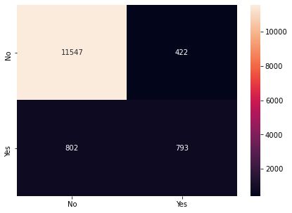

```python
# Get predicted classes
y_predict9 = xgbcl.predict(X2_test)

print(xgbcl.score(X2_test, y_test))

cm9=metrics.confusion_matrix(y_test, y_predict9, labels=[0, 1])

df_cm9 = pd.DataFrame(cm9, index = [i for i in ["No","Yes"]],
                  columns = [i for i in ["No","Yes"]])
plt.figure(figsize = (7,5))
sns.heatmap(df_cm9, annot=True ,fmt='g')
```

```python
# Create report for final evaluation of models at the end
report9 = classification_report(y_test, y_predict9, output_dict=True)
```

###### XGBoost Model Results - matrix X2

```python
TP = 793
FP = 422
FN = 802
TN = 11547
Recall = TP/(TP+FN)
Precision = TP/(TP+FP)
print('Recall [TP/(TP+FN)] for XGBoost_Ensemble = {0:.2f}'.format(Recall))
print('Precision [TP/(TP+FP)] for XGBoost_Ensemble = {0:.2f}'.format(Precision))
print('F1 Score [2.Precision.Recall / (Precision + Recall)] for XGBoost_Ensemble = {0:.2f}'.format((2*Recall*Precision)/(Recall+Precision)))
print('Accuracy [(TP+TN)/(TP+TN+FP+FN)] for XGBoost_Ensemble = {0:.2f}'.format((TP+TN)/(TP+TN+FP+FN)))
```

```
Recall [TP/(TP+FN)] for XGBoost_Ensemble = 0.50
Precision [TP/(TP+FP)] for XGBoost_Ensemble = 0.65
F1 Score [2.Precision.Recall / (Precision + Recall)] for XGBoost_Ensemble = 0.56
Accuracy [(TP+TN)/(TP+TN+FP+FN)] for XGBoost_Ensemble = 0.91
```

###### XGBoost Ensemble - matrix X3

```python
xgbcl.fit(X3_train, y_train)
```

```
XGBClassifier(base_score=0.2, booster='gbtree', colsample_bylevel=1,
              colsample_bynode=1, colsample_bytree=1, gamma=0, gpu_id=-1,
              importance_type='gain', interaction_constraints='',
              learning_rate=0.300000012, max_delta_step=0, max_depth=6,
              min_child_weight=1, missing=nan, monotone_constraints='()',
              n_estimators=100, n_jobs=0, num_parallel_tree=1, random_state=3,
              reg_alpha=0, reg_lambda=1, scale_pos_weight=1, subsample=1,
              tree_method='exact', validate_parameters=1, verbosity=None)
```

```
0.9092450604541433
```

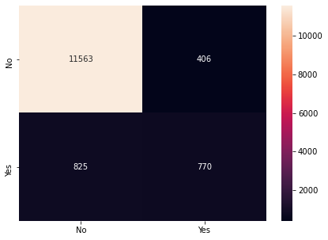

```python
# Get predicted classes
y_predict9 = xgbcl.predict(X3_test)

print(xgbcl.score(X3_test, y_test))

cm9=metrics.confusion_matrix(y_test, y_predict9, labels=[0, 1])

df_cm9 = pd.DataFrame(cm9, index = [i for i in ["No","Yes"]],
                  columns = [i for i in ["No","Yes"]])
plt.figure(figsize = (7,5))
sns.heatmap(df_cm9, annot=True ,fmt='g')
```

###### XGBoost Model Results - matrix X3

```python
TP = 770
FP = 406
FN = 825
TN = 11563
Recall = TP/(TP+FN)
Precision = TP/(TP+FP)
print('Recall [TP/(TP+FN)] for XGBoost_Ensemble = {0:.2f}'.format(Recall))
print('Precision [TP/(TP+FP)] for XGBoost_Ensemble = {0:.2f}'.format(Precision))
print('F1 Score [2.Precision.Recall / (Precision + Recall)] for XGBoost_Ensemble = {0:.2f}'.format((2*Recall*Precision)/(Recall+Precision)))
print('Accuracy [(TP+TN)/(TP+TN+FP+FN)] for XGBoost_Ensemble = {0:.2f}'.format((TP+TN)/(TP+TN+FP+FN)))
```

```
Recall [TP/(TP+FN)] for XGBoost_Ensemble = 0.48
Precision [TP/(TP+FP)] for XGBoost_Ensemble = 0.65
F1 Score [2.Precision.Recall / (Precision + Recall)] for XGBoost_Ensemble = 0.56
Accuracy [(TP+TN)/(TP+TN+FP+FN)] for XGBoost_Ensemble = 0.91
```

###### XGBoost performance using different matrices

- Precision increases from matrix X1 to X2, where we replace both duration & pdays outliers with the "maximum" duration & pdays respectively, as well as replace pdays -1 with mean of pdays

### Deliverable 3: Create Ensembe Model: DataFrame to compare models and their metrics

```python
# Initial list of lists
models = [['LogisticRegression', report1['accuracy'], report1['1']['f1-score'], report1['1']['recall'], report1['1']['precision']],
          ['DecisionTree', report3['accuracy'], report3['1']['f1-score'], report3['1']['recall'], report3['1']['precision']],
          ['Bagging', report4['accuracy'], report4['1']['f1-score'], report4['1']['recall'], report4['1']['precision']],
          ['RandomForest', report5['accuracy'], report5['1']['f1-score'], report5['1']['recall'], report5['1']['precision']],
          ['AdaBoost', report6['accuracy'], report6['1']['f1-score'], report6['1']['recall'], report6['1']['precision']],
          ['GradientBoost', report7['accuracy'], report7['1']['f1-score'], report7['1']['recall'], report7['1']['precision']],
          ['CatBoost', report8['accuracy'], report8['1']['f1-score'], report8['1']['recall'], report8['1']['precision']],
          ['XGBoost', report9['accuracy'], report9['1']['f1-score'], report9['1']['recall'], report9['1']['precision']]]

# Create dataframe
modelsResult = pd.DataFrame(models, columns = ['Model', 'Accuracy', 'F1-Score', 'Recall', 'Precision'])
print(modelsResult)
```

```
                Model  Accuracy  F1-Score    Recall  Precision
0  LogisticRegression  0.903716  0.470827  0.364263   0.665521
1        DecisionTree  0.898997  0.537162  0.498433   0.582418
2             Bagging  0.905116  0.534202  0.462696   0.631849
3        RandomForest  0.909319  0.544444  0.460815   0.665158
4            AdaBoost  0.903937  0.488819  0.390596   0.653040
5       GradientBoost  0.909466  0.533080  0.439498   0.677295
6            CatBoost  0.909319  0.560086  0.490909   0.651957
7             XGBoost  0.909761  0.564413  0.497179   0.652675
```

```python
# Sort Model DataFrame entries in descending order according to F1-Score, Recall and finally Precision
modelsResult.sort_values(by=['F1-Score', 'Recall', 'Precision'], ascending=False)
```

|  | Model | Accuracy | F1-Score | Recall | Precision |
| --- | --- | --- | --- | --- | --- |
| 7 | XGBoost | 0.909761 | 0.564413 | 0.497179 | 0.652675 |
| 6 | CatBoost | 0.909319 | 0.560086 | 0.490909 | 0.651957 |
| 3 | RandomForest | 0.909319 | 0.544444 | 0.460815 | 0.665158 |
| 1 | DecisionTree | 0.898997 | 0.537162 | 0.498433 | 0.582418 |
| 2 | Bagging | 0.905116 | 0.534202 | 0.462696 | 0.631849 |
| 5 | GradientBoost | 0.909466 | 0.533080 | 0.439498 | 0.677295 |
| 4 | AdaBoost | 0.903937 | 0.488819 | 0.390596 | 0.653040 |
| 0 | LogisticRegression | 0.903716 | 0.470827 | 0.364263 | 0.665521 |

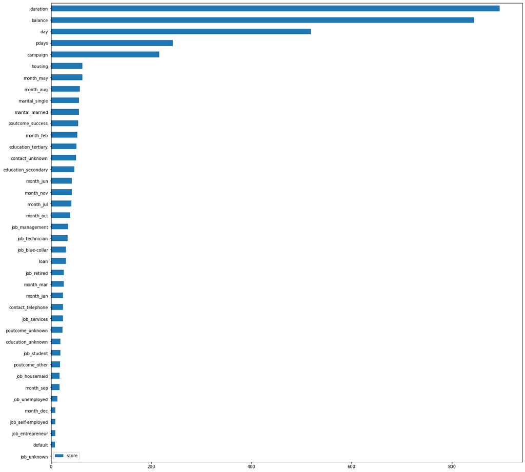

```python
# Display feature importance of best algorithm XGBoost
important_features = xgbcl.get_booster().get_score(importance_type='weight')
fValues = list(important_features.values())
fKeys = list(important_features.keys())

dataF = pd.DataFrame(index=fKeys, data=fValues, columns=['score']).sort_values(by='score')
dataF.plot(kind='barh', figsize=(20, 20))
```